# nb_main

Q1.

We use Monte carlo method to evaluate each position's value on a $\textbf{tic tac toe board}$. Over several episodes of agent playing an opponent who plays random moves, we let the agent learns the value of each position on the game board. We learn that when the agent plays second, center position is given max value, followed by corners and then sides. But it doesn't learn any game strategies like block opponent or aim for 3 X's in a row etc. It could be done with two semi trained agents playing with each other I hope.

[figure not shown]

```
SAMPLE RUN
```

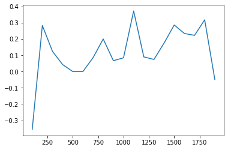

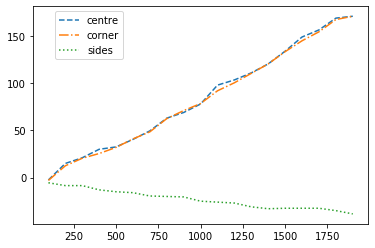

```python
# Opponent makes a move first and agent makes the next move
import numpy as np
import pandas as pd
import matplotlib.pyplot as plt
from collections import Counter
from tqdm import tqdm
import pickle

# state - available positions, action: next move, method: On-policy Monte Carlo
matrix = np.zeros(9) # The game board
value_matrix = (np.ones(9))*0.5  # agent plays second # Stores V(s) values

episode = np.arange(2000)


# Random selection of an available position from the opponent. Also, update board with the selection -1 at the selected position
def opponent_selection():
    available_positions = np.where(matrix==0)[0]
    opponent_selection = np.random.choice(available_positions)
    matrix[opponent_selection] = -1
    return opponent_selection

# Random selection of an available position from the agent. And update board with the selection 1 at the selected position
def agent_random():
    available_positions = np.where(matrix==0)[0]
    agent_selection = np.random.choice(available_positions)
    matrix[agent_selection] = 1
    return agent_selection

# selection by the agent following a greedy policy based on a state value function
def agent_greedy():
    available_positions = np.where(matrix==0)[0]
    inter_value = np.where(value_matrix == (value_matrix[available_positions].max()))[0]
    final_values = []
    for i,x in enumerate(inter_value):
        for k,y in enumerate(available_positions):
            if x == y:
                final_values.append(x)
    agent_selection = np.random.choice(final_values)
    matrix[agent_selection] = 1
    return agent_selection

# rewards for a given board state
def game_points():
    agent_win = np.array([1,1,1])
    opponent_win = np.array([-1,-1,-1])
    if ((matrix[0:3] == agent_win).all() | (matrix[0::4] == agent_win).all() | (matrix[0::3] == agent_win).all() | (matrix[1::3] == agent_win).all()
        | (matrix[2::3] == agent_win).all() | (matrix[2:8:2] == agent_win).all() | (matrix[3:6] == agent_win).all() | (matrix[6:9] == agent_win).all()):
        return 1
    elif ((matrix[0:3] == opponent_win).all() | (matrix[0::4] == opponent_win).all() | (matrix[0::3] == opponent_win).all() | (matrix[1::3] == opponent_win).all()
        | (matrix[2::3] == opponent_win).all() | (matrix[2:8:2] == opponent_win).all() | (matrix[3:6] == opponent_win).all() | (matrix[6:9] == opponent_win).all()):
        return -1
    else:
        return 0

# check if agent wins
def agent_wins():
    agent_win = np.array([1,1,1])
    if ((matrix[0:3] == agent_win).all() | (matrix[0::4] == agent_win).all() | (matrix[0::3] == agent_win).all() | (matrix[1::3] == agent_win).all()
        | (matrix[2::3] == agent_win).all() | (matrix[2:8:2] == agent_win).all() | (matrix[3:6] == agent_win).all() | (matrix[6:9] == agent_win).all()):
        return 1
    else:
        return -1



# update state value function based on game_points from e number of episodes with sgent playing second
# opponent first
# On-policy Monte carlo method of reinforcement learning
reward=0
rewards = []
plot_rewards = []
plot_rewards_unique = []
plot_x = []
episode_all = []
episodes_unique = 0
value_matrix_record_centre = []
value_matrix_record_corners = []
value_matrix_record_sides = []
for e in tqdm(episode):
    plt.clf()
    matrix = np.zeros(9)
    turn = 0
    opponent_selections= []
    agent_selections = []
    episode_ep = []
    if e == 0:
        while ((game_points() == 0) &  (turn < 8)):
            #print(turn)
            episode_ep_opp = []
            episode_ep_agent = []
            opp_choice = opponent_selection()
            opponent_selections.append(opp_choice)
            #plot_matrix(opponent_selections[-1],False)
            turn += 1
            mat = matrix.tolist()
            # print(opp_choice)
            mat.append(opp_choice)
            # print(mat)
            episode_ep_opp.extend(mat)
            if ((turn <=7) and (game_points() == 0)):
                agent_choice = agent_random()
                agent_selections.append(agent_choice)
                #plot_matrix(agent_selections[-1],True)
                turn += 1
                mat = matrix.tolist()
                mat.append(agent_choice)
                episode_ep_agent.extend(mat)
            else:
                continue
            extend_episode = episode_ep_opp.append(reward)
            episode_ep_2 = episode_ep_opp + episode_ep_agent
            # print(episode_ep_2)
            episode_ep.extend(episode_ep_2)

            # episode_ep.append(episode_ep_agent)
        reward = agent_wins()   # draw and lose are considered equally bad
        value_matrix[agent_selections] += 0.5*(reward)
        rewards.append(reward)
        episode_ep.append(reward)
        # print(episode_ep)
        episode_all.append(episode_ep)
        # value_matrix_record_centre.append(value_matrix[4])
    else:
        while ((game_points() == 0) &  (turn <= 7)):
            #print(turn)
            epsilon = np.random.rand(1)
            episode_ep_opp = []
            episode_ep_agent = []
            opp_choice = opponent_selection()
            opponent_selections.append(opp_choice)
            #plot_matrix(opponent_selections[-1],False)
            turn += 1
            mat = matrix.tolist()
            # print(opp_choice)
            mat.append(opp_choice)
            # print(mat)
            episode_ep_opp.extend(mat)
            if ((turn <=7) and (game_points() == 0)):
                if epsilon < 0.1:
                    agent_choice = agent_random()
                    agent_selections.append(agent_choice)
                    mat = matrix.tolist()
                    mat.append(agent_choice)
                    episode_ep_agent.extend(mat)
                else:
                    agent_choice = agent_greedy()
                    agent_selections.append(agent_choice)
                    mat = matrix.tolist()
                    mat.append(agent_choice)
                    episode_ep_agent.extend(mat)
                #plot_matrix(agent_selections[-1],True)
                turn += 1
            else:
                continue
            extend_episode = episode_ep_opp.append(reward)
            episode_ep_2 = episode_ep_opp + episode_ep_agent
            # print(episode_ep_2)
            episode_ep.extend(episode_ep_2)
            # print(e,matrix)
        reward = agent_wins()   # draw and lose are considered equally bad
        value_matrix[agent_selections] += 0.5*(reward)
        rewards.append(reward)
        episode_ep.append(reward)
        episode_all.append(episode_ep)

        if e%100 == 0:
            plot_rewards.append(sum(rewards[e-100:e])/100)
            plot_x.append(e)
            episodes_uniq_avg = len(Counter([tuple(i) for i in episode_all])) - episodes_unique
            episodes_unique = len(Counter([tuple(i) for i in episode_all]))
            plot_rewards_unique.append(sum(rewards[e-100:e])/episodes_uniq_avg)
            value_matrix_record_centre.append(value_matrix[4])
            value_matrix_record_corners.append(value_matrix[2])
            value_matrix_record_sides.append(value_matrix[7])
        # print(episode_ep)
# print(rewards)
# In[5]:
# print(episode_all)
# print(plot_x)
# print(plot_rewards)

episodes_unique = Counter([tuple(i) for i in episode_all])
# episodes_unique = len(set(episode_all))
# print(len(episodes_unique))
# print(sum(rewards))
print("SAMPLE RUN")
fig1 = plt.figure()
plt.plot(plot_x,plot_rewards_unique)
plt.show()

#### Code agent 2nd
# file = open("tictactoe_matrix.pkl","wb")
# pickle.dump(value_matrix,file)
plt.plot(plot_x,value_matrix_record_centre,linestyle = '--',label = 'centre',linewidth = 1.5)
plt.plot(plot_x,value_matrix_record_corners,linestyle = '-.',label = 'corner',linewidth = 1.5)
plt.plot(plot_x,value_matrix_record_sides,linestyle = ':',label = 'sides',linewidth = 1.5)
plt.legend(bbox_to_anchor=(0.05, 1), loc='upper left')
plt.show()
```

Plot:

(a)No. of episodes versus return confidence return over 100 episodes

The agent can be trained with different rewards for different games. For example agent can get a reward of -1 for both draw and losing the game or it can get a reward of 0 on both the occassions.

Fig 1. reward = -1

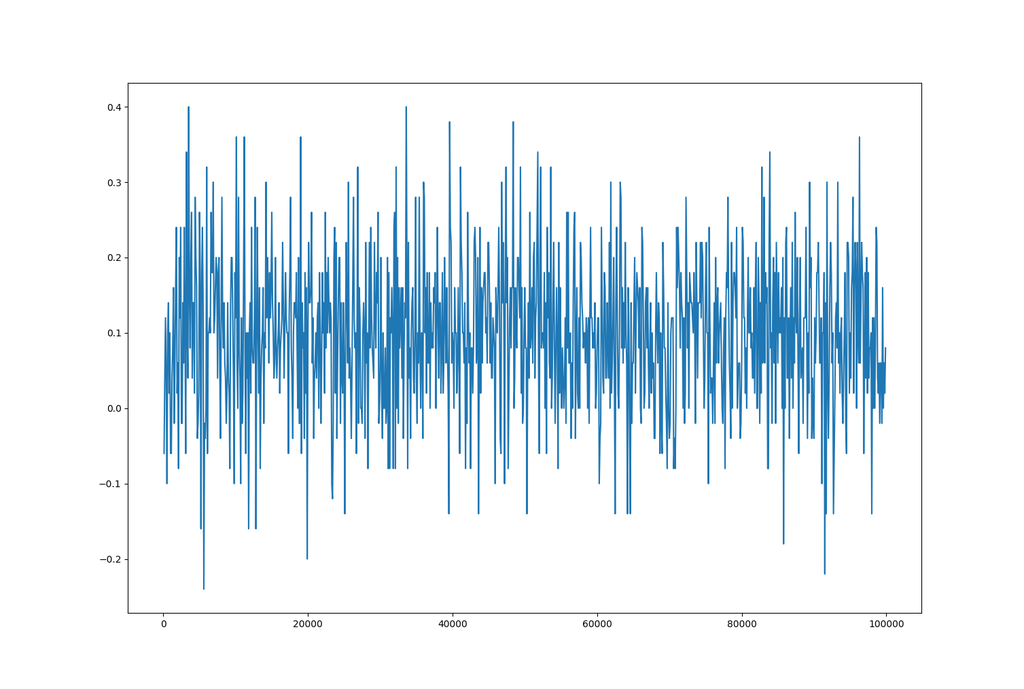

Fig 2. reward = 0

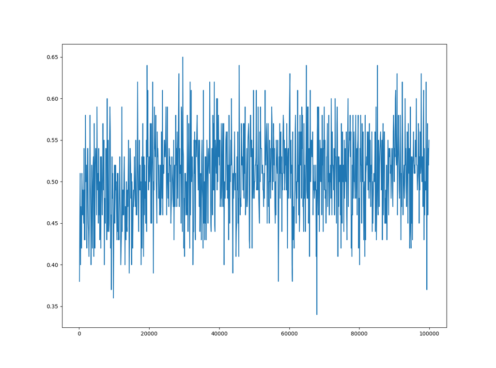

We can see that average reward is higher when there is less negative reinforcement for the agent. Which might mean that agent might not be learning complex stratergies even as episodes go up when opponent is random.

(b)

Number of unique episodes so-far versus return confidence intervals over 100 episodes.

[figure not shown]

The graph shows on policy monte carlo method training

(c) Studying the state values of the tic tac toe board.

[figure not shown]

From the graph we are able to understand that the centre, corner and sides have different importances. The agent is able to learn this over several episodes.

```python
## Tic TAc Toe Test File
# Play the game with a greedy agent and a random opponent
import numpy as np
import pandas as pd
import matplotlib.pyplot as plt
import pickle
def opponent_selection():
    available_positions = np.where(matrix==0)[0]
    opponent_selection = np.random.choice(available_positions)
    matrix[opponent_selection] = -1
    return opponent_selection

def agent_greedy():
    available_positions = np.where(matrix==0)[0]
    inter_value = np.where(value_matrix == (value_matrix[available_positions].max()))[0]
    final_values = []
    for i,x in enumerate(inter_value):
        for k,y in enumerate(available_positions):
            if x == y:
                final_values.append(x)
    agent_selection = np.random.choice(final_values)
    matrix[agent_selection] = 1
    return agent_selection

def game_points():
    agent_win = np.array([1,1,1])
    opponent_win = np.array([-1,-1,-1])
    if ((matrix[0:3] == agent_win).all() | (matrix[0::4] == agent_win).all() | (matrix[0::3] == agent_win).all() | (matrix[1::3] == agent_win).all()
        | (matrix[2::3] == agent_win).all() | (matrix[2:8:2] == agent_win).all() | (matrix[3:6] == agent_win).all() | (matrix[6:9] == agent_win).all()):
        return 1
    elif ((matrix[0:3] == opponent_win).all() | (matrix[0::4] == opponent_win).all() | (matrix[0::3] == opponent_win).all() | (matrix[1::3] == opponent_win).all()
        | (matrix[2::3] == opponent_win).all() | (matrix[2:8:2] == opponent_win).all() | (matrix[3:6] == opponent_win).all() | (matrix[6:9] == opponent_win).all()):
        return -1
    else:
        return 0

file = open("tictactoe_matrix.pkl","rb")
value_matrix = pickle.load(file)
matrix = np.zeros(9)
def play_game():
    turn =0
    opponent_selections= []
    agent_selections = []
    while ((game_points() == 0) &  (turn < 8)):
        #print(turn)
        opponent_selections.append(opponent_selection())
        #opponent_selections.append(opponent_greedy())
        print(np.where(matrix==0))
        # plot_matrix(opponent_selections[-1],False)
        turn += 1
        if ((turn <=7) and (game_points() == 0)):
            agent_selections.append(agent_greedy())
            print(np.where(matrix==0))
            # plot_matrix(agent_selections[-1],True)
            turn += 1
        else:
            continue
        reward = game_points()
    print(" ",matrix[0:3])
    print(" ",matrix[3:6])
    print(" ",matrix[6:9])
    # print(game_points(), agent_selections,opponent_selections)
    if game_points() == 1:
        print('agent wins')
    elif game_points() == -1:
        print('opponent wins')
    else:
        print('draw')
play_game()
```

```
(array([0, 1, 2, 3, 4, 5, 7, 8]),)
(array([1, 2, 3, 4, 5, 7, 8]),)
(array([1, 2, 4, 5, 7, 8]),)
(array([1, 2, 5, 7, 8]),)
(array([1, 5, 7, 8]),)
(array([1, 5, 7]),)
  [ 1.  0. -1.]
  [-1.  1.  0.]
  [-1.  0.  1.]
agent wins
```

Q2.

```python
##Code for 8x8 frozen lake train code
import numpy as np
import gym
import random
import matplotlib.pyplot as plt
import pickle
env = gym.make("FrozenLake8x8-v0",is_slippery = True)
action_size = env.action_space.n
state_size = env.observation_space.n
# print(env.action_space.n)
qtable = np.ones((state_size, action_size))*0.2
# print(qtable)

# total_episodes = 500000        # Total episodes
# learning_rate = 0.000009           # Learning rate
# max_steps = 1000000             # Max steps per episode
# gamma = 0.96                  # Discounting rate

# # Exploration parameters
# epsilon = 1.0                 # Exploration rate
# max_epsilon = 1.0             # Exploration probability at start
# min_epsilon = 0.1            # Minimum exploration probability
# decay_rate = 0.005             # Exponential decay rate for exploration prob

total_episodes = 500000        # Total episodes
learning_rate = 0.09           # Learning rate
max_steps = 1000000             # Max steps per episode
gamma = 0.99                  # Discounting rate

# Exploration parameters
epsilon = 0.9                 # Exploration rate
max_epsilon = 1.0             # Exploration probability at start
min_epsilon = 0.01            # Minimum exploration probability
decay_rate = 0.05             # Exponential decay rate for exploration prob

# List of rewards
rewards = []
plot_rewards = []
plot_episodes = []
reward_per_k =0
# 2 For life or until learning is stopped
for episode in range(total_episodes):
    # Reset the environment
    state = env.reset()
    step = 0
    done = False
    total_rewards = 0
    if episode%10000 == 0:
        if learning_rate*2 < 1.0:
            learning_rate *= 2

    for step in range(max_steps):
        # 3. Choose an action a in the current world state (s)
        ## First we randomize a number
        exp_exp_tradeoff = random.uniform(0, 1)

        ## If this number > greater than epsilon --> exploitation (taking the biggest Q value for this state)
        if exp_exp_tradeoff > epsilon:
            action = np.argmax(qtable[state,:])

        # Else doing a random choice --> exploration
        else:
            action = env.action_space.sample()

        # Take the action (a) and observe the outcome state(s') and reward (r)
        new_state, reward, done, info = env.step(action)

        # Update Q(s,a):= Q(s,a) + lr [R(s,a) + gamma * max Q(s',a') - Q(s,a)]
        # qtable[new_state,:] : all the actions we can take from new state
        qtable[state, action] = qtable[state, action] + learning_rate * (reward + gamma * np.max(qtable[new_state, :]) - qtable[state, action])

        total_rewards += reward

        # Our new state is state
        state = new_state

        # If done (if we're dead) : finish episode
        if done == True:
            break

    # Reduce epsilon (because we need less and less exploration)
    epsilon = min_epsilon + (max_epsilon - min_epsilon)*np.exp(-decay_rate*episode)
    rewards.append(total_rewards)
    # print ("Score over time: " +  str(sum(rewards)/total_episodes))
    reward_per_k += total_rewards
    if episode%100 == 0:
        print("average reward over " + str(episode) + " episodes is " +str(sum(rewards)/total_episodes) )
    if episode%100 == 0:
        plot_rewards.append(reward_per_k/100)
        reward_per_k = 0
        plot_episodes.append(episode)
print(qtable)
# file = open("qlearn.pkl",'wb')
# pickle.dump(qtable,file)
fig = plt.figure(1)
plt.plot(plot_episodes,plot_rewards)
plt.show()
env.reset()
```

```
average reward over 0 episodes is 0.0
average reward over 100 episodes is 0.0
average reward over 200 episodes is 0.0
average reward over 300 episodes is 0.0
average reward over 400 episodes is 0.0
average reward over 500 episodes is 0.0
average reward over 600 episodes is 2e-06
average reward over 700 episodes is 2e-06
average reward over 800 episodes is 4e-06
average reward over 900 episodes is 4e-06
average reward over 1000 episodes is 6e-06
average reward over 1100 episodes is 6e-06
average reward over 1200 episodes is 6e-06
average reward over 1300 episodes is 6e-06
average reward over 1400 episodes is 8e-06
average reward over 1500 episodes is 1e-05
average reward over 1600 episodes is 1e-05
average reward over 1700 episodes is 1e-05
average reward over 1800 episodes is 1.4e-05
average reward over 1900 episodes is 1.4e-05
average reward over 2000 episodes is 1.4e-05
average reward over 2100 episodes is 1.8e-05
average reward over 2200 episodes is 1.8e-05
average reward over 2300 episodes is 1.8e-05
average reward over 2400 episodes is 1.8e-05
average reward over 2500 episodes is 1.8e-05
average reward over 2600 episodes is 1.8e-05
average reward over 2700 episodes is 1.8e-05
average reward over 2800 episodes is 2e-05
average reward over 2900 episodes is 2.4e-05
average reward over 3000 episodes is 2.4e-05
average reward over 3100 episodes is 2.4e-05
average reward over 3200 episodes is 2.4e-05
average reward over 3300 episodes is 2.4e-05
average reward over 3400 episodes is 2.4e-05
average reward over 3500 episodes is 2.6e-05
average reward over 3600 episodes is 2.6e-05
average reward over 3700 episodes is 2.6e-05
average reward over 3800 episodes is 2.6e-05
average reward over 3900 episodes is 2.6e-05
```

[output cut: 135 more lines]

```
average reward over 17500 episodes is 0.01082
average reward over 17600 episodes is 0.010974
average reward over 17700 episodes is 0.011118
average reward over 17800 episodes is 0.011274
average reward over 17900 episodes is 0.011416
average reward over 18000 episodes is 0.011558
average reward over 18100 episodes is 0.011696
average reward over 18200 episodes is 0.011844
average reward over 18300 episodes is 0.012002
average reward over 18400 episodes is 0.012122
average reward over 18500 episodes is 0.012232
average reward over 18600 episodes is 0.01236
average reward over 18700 episodes is 0.012496
average reward over 18800 episodes is 0.012652
average reward over 18900 episodes is 0.012784
```

[output not shown]

This figure shows training over 8x8 frozen lake with Q learning. This was achieved by favouring exploration more.

1. Setting qtable values as non zero
2. Setting gamma = 0.99

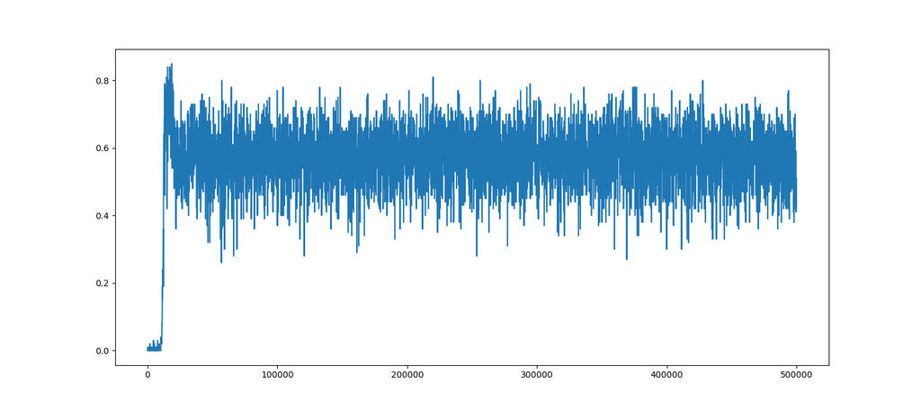

Qlearning This figure shows training over 4x4 frozen lake

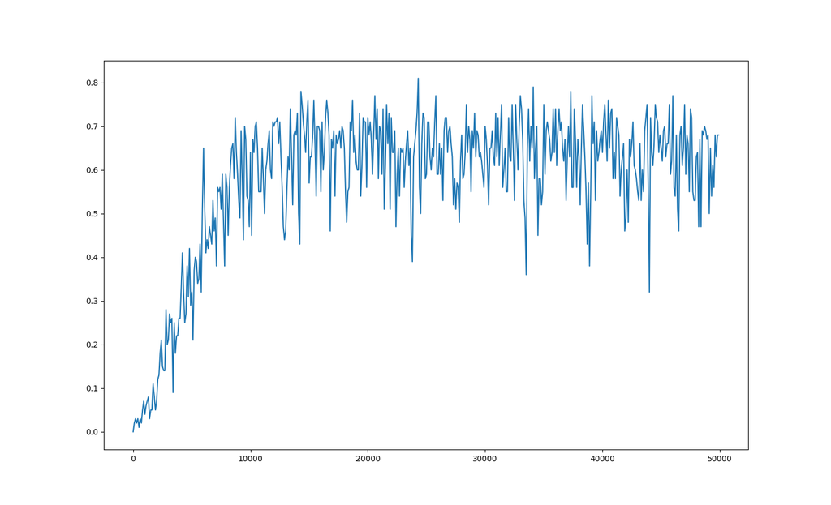

```python
# Code for testing Qlearning
import pickle
import gym
import numpy as np
env = gym.make("FrozenLake8x8-v0")
max_steps = 1000000
file = open("qlearn.pkl",'rb')
qtable = pickle.load(file)
for episode in range(5):
    state = env.reset()
    step = 0
    done = False

    print("EPISODE ", episode)

    for step in range(max_steps):

        # Take the action (index) that have the maximum expected future reward given that state
        action = np.argmax(qtable[state,:])

        new_state, reward, done, info = env.step(action)

        if done:
            # Here, we decide to only print the last state (to see if our agent is on the goal or fall into an hole)
            env.render()

            # We print the number of step it took.
            print("Number of steps", step)
            break
        state = new_state
env.close()
```

```
---------------------------------------------------------------------------
FileNotFoundError                         Traceback (most recent call last)
<ipython-input-8-7b6ff5f93eeb> in <module>
      5 env = gym.make("FrozenLake8x8-v0")
      6 max_steps = 1000000
----> 7 file = open("qlearn.pkl",'rb')
      8 qtable = pickle.load(file)
      9 for episode in range(5):

FileNotFoundError: [Errno 2] No such file or directory: 'qlearn.pkl'
```

SARSA Frozen Lake

```python
import numpy as np
import gym
import random
import matplotlib.pyplot as plt
import pickle
env = gym.make("FrozenLake-v0",is_slippery = True)

action_size = env.action_space.n
state_size = env.observation_space.n

qtable = np.zeros((state_size, action_size))
# print(qtable)

total_episodes = 50000        # Total episodes
learning_rate = 0.09           # Learning rate
max_steps = 1000000             # Max steps per episode
gamma = 0.95                  # Discounting rate

# Exploration parameters
epsilon = 1.0                 # Exploration rate
max_epsilon = 1.0             # Exploration probability at start
min_epsilon = 0.1            # Minimum exploration probability
decay_rate = 0.01             # Exponential decay rate for exploration prob

# List of rewards
rewards = []
plot_rewards = []
plot_episodes = []
reward_per_k =0
# 2 For life or until learning is stopped
for episode in range(total_episodes):
    # Reset the environment
    state = env.reset()
    step = 0
    done = False
    total_rewards = 0
    # if episode%1000 == 0:
    #     learning_rate *= 5


    for step in range(max_steps):
        # 3. Choose an action a in the current world state (s)
        ## First we randomize a number
        exp_exp_tradeoff = random.uniform(0, 1)

        ## If this number > greater than epsilon --> exploitation (taking the biggest Q value for this state)
        if exp_exp_tradeoff > epsilon:
            action = np.argmax(qtable[state,:])

        # Else doing a random choice --> exploration
        else:
            action = env.action_space.sample()

        # Take the action (a) and observe the outcome state(s') and reward (r)
        new_state, reward, done, info = env.step(action)

        # Create the new action
        if exp_exp_tradeoff > epsilon:
            new_action = np.argmax(qtable[new_state,:])
        else:
            new_action = env.action_space.sample()

        qtable[state, action] = qtable[state, action] + learning_rate * (reward + gamma * qtable[new_state, new_action] - qtable[state, action])

        total_rewards += reward

        # Our new state is state
        state = new_state

        # If done (if we're dead) : finish episode
        if done == True:
            break

    # Reduce epsilon (because we need less and less exploration)
    epsilon = min_epsilon + (max_epsilon - min_epsilon)*np.exp(-decay_rate*episode)
    rewards.append(total_rewards)
    # print ("Score over time: " +  str(sum(rewards)/total_episodes))
    reward_per_k += total_rewards
    if episode%1000 == 0:
        print("average reward over " + str(episode) + " episodes is " +str(sum(rewards)/total_episodes) )
    if episode%100 == 0:
        plot_rewards.append(reward_per_k/100)
        reward_per_k = 0
        plot_episodes.append(episode)
print(qtable)
# file = open("sarsa.pkl",'wb')
# pickle.dump(qtable,file)
fig = plt.figure(1)
plt.plot(plot_episodes,plot_rewards)
plt.show()
env.reset()
```

```
average reward over 0 episodes is 0.0
average reward over 1000 episodes is 0.00166
average reward over 2000 episodes is 0.00732
average reward over 3000 episodes is 0.01424
average reward over 4000 episodes is 0.02074
average reward over 5000 episodes is 0.02834
average reward over 6000 episodes is 0.03598
average reward over 7000 episodes is 0.04306
```

```
---------------------------------------------------------------------------
KeyboardInterrupt                         Traceback (most recent call last)
<ipython-input-10-3661ecd63133> in <module>
     53
     54         # Take the action (a) and observe the outcome state(s') and reward (r)
---> 55         new_state, reward, done, info = env.step(action)
     56
     57         # Create the new action

KeyboardInterrupt:
```

This figure shows training over 4x4 frozen lake with sarsa

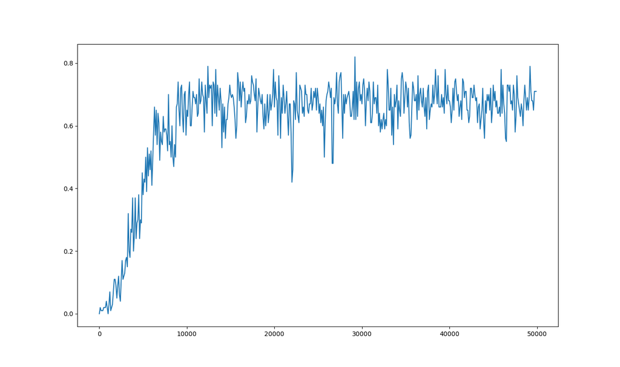

```python
## Code for testing SARSA
import pickle
import gym
import numpy as np
env = gym.make("FrozenLake-v0",is_slippery = True)
max_steps = 1000000
file = open("sarsa.pkl",'rb')
qtable = pickle.load(file)
for episode in range(5):
    step = 0
    done = False
    state = env.reset()


    print("EPISODE ", episode)

    for step in range(max_steps):

        # Take the action (index) that have the maximum expected future reward given that state
        action = np.argmax(qtable[state,:])

        new_state, reward, done, info = env.step(action)

        if done:
            # Here, we decide to only print the last state (to see if our agent is on the goal or fall into an hole)
            env.render()

            # We print the number of step it took.
            print("Number of steps", step)
            break
        state = new_state
env.close()
```

Expected SARSA

```python
## Code for training expected SARSA
import numpy as np
import gym
import random
import matplotlib.pyplot as plt
import pickle
env = gym.make("FrozenLake-v0",is_slippery = True)

action_size = env.action_space.n
state_size = env.observation_space.n

qtable = np.zeros((state_size, action_size))
# print(qtable)


# Exploration parameters

max_epsilon = 1.0             # Exploration probability at start
min_epsilon = 0.01            # Minimum exploration probability

total_episodes = 500000        # Total episodes
learning_rate = 0.09           # Learning rate


epsilon = 1.0                 # Exploration rate
decay_rate = 0.0005             # Exponential decay rate for exploration prob

max_steps = 1000000             # Max steps per episode
gamma = 0.95                  # Discounting rate

# List of rewards
rewards = []
plot_rewards = []
plot_episodes = []
reward_per_k =0
# 2 For life or until learning is stopped
for episode in range(total_episodes):
    # Reset the environment
    state = env.reset()
    step = 0

    total_rewards = 0
    done = False

    for step in range(max_steps):
        # 3. Choose an action a in the current world state (s)
        ## First we randomize a number
        exp_exp_tradeoff = random.uniform(0, 1)

        ## If this number > greater than epsilon --> exploitation (taking the biggest Q value for this state)
        if exp_exp_tradeoff > epsilon:
            action = np.argmax(qtable[state,:])

        # Else doing a random choice --> exploration
        else:
            action = env.action_space.sample()

        # Take the action (a) and observe the outcome state(s') and reward (r)
        new_state, reward, done, info = env.step(action)

        # Create the new action
        if exp_exp_tradeoff > epsilon:
            new_action = np.argmax(qtable[new_state,:])
        else:
            new_action = env.action_space.sample()

        expected_value = np.mean(qtable[new_state, :]) #np.max(qtable[new_state, :])
        qtable[state, action] = qtable[state, action] + learning_rate * (reward + gamma * expected_value - qtable[state, action])

        total_rewards += reward

        # Our new state is state
        state = new_state

        # If done (if we're dead) : finish episode
        if done == True:
            break

    # Reduce epsilon (because we need less and less exploration)
    epsilon = min_epsilon + (max_epsilon - min_epsilon)*np.exp(-decay_rate*episode)
    rewards.append(total_rewards)
    # print ("Score over time: " +  str(sum(rewards)/total_episodes))
    reward_per_k += total_rewards
    if episode%1000 == 0:
        print("average reward over " + str(episode) + " episodes is " +str(sum(rewards)/total_episodes) )
    if episode%100 == 0:
        plot_rewards.append(reward_per_k/100)
        reward_per_k = 0
        plot_episodes.append(episode)
print(qtable)
file = open("exp_sarsa.pkl",'wb')
pickle.dump(qtable,file)
fig = plt.figure(1)
plt.plot(plot_episodes,plot_rewards)
plt.show()
env.reset()
```

```
average reward over 0 episodes is 0.0
average reward over 1000 episodes is 4e-05
average reward over 2000 episodes is 0.000126
average reward over 3000 episodes is 0.000302
average reward over 4000 episodes is 0.000524
average reward over 5000 episodes is 0.00081
average reward over 6000 episodes is 0.001112
average reward over 7000 episodes is 0.001506
average reward over 8000 episodes is 0.001846
average reward over 9000 episodes is 0.002244
average reward over 10000 episodes is 0.002628
average reward over 11000 episodes is 0.003018
average reward over 12000 episodes is 0.003616
average reward over 13000 episodes is 0.004036
average reward over 14000 episodes is 0.004392
```

[output not shown]

This figure shows training over 4x4 frozen lake with expected sarsa

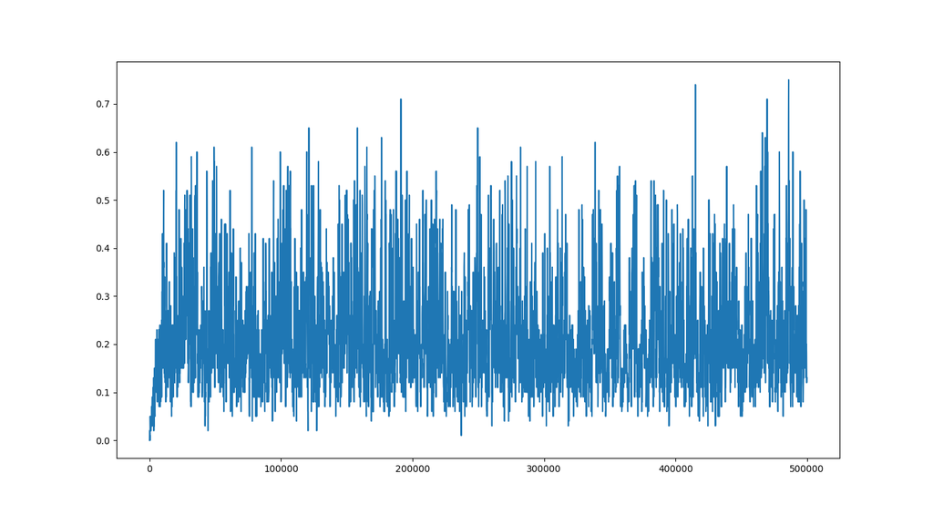

```python
## Code for testing expected sarsa
import pickle
import gym
import numpy as np
env = gym.make("FrozenLake-v0",is_slippery = True)
max_steps = 1000000
file = open("exp_sarsa.pkl",'rb')
qtable = pickle.load(file)
for episode in range(5):
    state = env.reset()
    step = 0
    done = False

    print("EPISODE ", episode)

    for step in range(max_steps):

        # Take the action (index) that have the maximum expected future reward given that state
        action = np.argmax(qtable[state,:])

        new_state, reward, done, info = env.step(action)

        if done:
            # Here, we decide to only print the last state (to see if our agent is on the goal or fall into an hole)
            env.render()

            # We print the number of step it took.
            print("Number of steps", step)
            break
        state = new_state
env.close()
```

Q3.

```python
## Train Deep Q Network
import random
import gym
import numpy as np
from keras.models import Model, Input
from keras.layers import Conv2D, Flatten, Dense, BatchNormalization
from keras.optimizers import Adam
from keras.preprocessing import image
from keras import losses


class Transition(object):
    def __init__(self, sequence, action, observation, reward, done):
        self.sequence = sequence
        self.action = action
        self.observation = observation
        self.reward = reward
        self.done = done

## The DQN Agent tht's learning to play breakout
class Agent(object):
    # Fixing Parameters for learning
    MINIBATCH_SIZE = 32              # Batch Size
    REPLAY_MEMORY_SIZE = 1e6         # Replay Buffer

    UPDATE_FREQUENCY = 4
    LEARNING_RATE = 0.000025
    INITIAL_EXPLORATION = 1.0
    FINAL_EXPLORATION = 0.1

    FINAL_EXPLORATION_FRAME = 1e6
    REPLAY_START_SIZE = 50000

    AGENT_HISTORY_LENGTH = 4
    TARGET_NETWORK_UPDATE_FREQUENCY = 1e4
    GAMMA = 0.99
    ACTION_REPEAT = 4
    ## Images width and height
    IMG_WIDTH = 48
    IMG_HEIGHT = 48
    IMG_SIZE = (IMG_HEIGHT, IMG_WIDTH)
    NUM_OF_ACTIONS = 4

    ## Creating two Q networks, one from time T-1 and the other for time T
    def __init__(self):
        self.Q = self.get_model()
        self.Q_ = self.copy_model(self.Q)
        self.transitions = []
        self.train_minibatches = []
        self.exploration_factor = self.INITIAL_EXPLORATION
        self.env = gym.make("Breakout-v0")
        self.steps = 0

    # Get the action from the trained network
    def get_predicted_action(self, sequence):
        prediction = self.Q.predict(np.asarray([np.stack(sequence, -1)]))[0]
        return np.argmax(prediction)

    # Saving weights which need to be copied for each iteration
    def copy_model(self, model):
        model.save_weights('weights.h5')
        new_model = self.get_model()
        new_model.load_weights('weights.h5')
        return new_model

    # Exploration being introduced
    def get_action(self, sequence):
        n = np.random.uniform()
        if n <= self.exploration_factor:
            return self.env.action_space.sample()
        return self.get_predicted_action(sequence)
    # Create the CNN model
    def get_model(self):
        input_layer = Input(shape=(self.IMG_HEIGHT, self.IMG_WIDTH, self.AGENT_HISTORY_LENGTH))
        layer = BatchNormalization()(input_layer)
        layer = Conv2D(32, (8, 8), strides=(4, 4), activation='relu', data_format="channels_last", padding='same')(layer)
        layer = BatchNormalization()(layer)
        layer = Conv2D(32, (4, 4), strides=(2, 2), activation='relu', data_format="channels_last", padding='same')(layer)
        layer = BatchNormalization()(layer)
        layer = Conv2D(64, (3, 3), strides=(1, 1), activation='relu', data_format="channels_last", padding='same')(layer)
        layer = Flatten()(layer)
        layer = BatchNormalization()(layer)
        layer = Dense(512, activation='relu')(layer)
        layer = BatchNormalization()(layer)
        output_layer = Dense(self.NUM_OF_ACTIONS)(layer)
        model = Model(input_layer, output_layer)
        model.compile(Adam(self.LEARNING_RATE), loss=losses.mean_squared_error, metrics=['accuracy']) ## Using Adam solver
        return model

    # Execution
    def run(self, episodes, render=False, do_train=True):
        for episode in range(episodes):
            observation = self.env.reset()
            observation = self.pre_process_observation(observation)
            sequence = [observation]*self.AGENT_HISTORY_LENGTH
            done = False

            action = 0
            while not done:
                if render:
                    self.env.render()
                if self.steps % self.ACTION_REPEAT == 0:
                    action = self.get_action(sequence)
                observation, reward, done, info = self.env.step(action)
                observation = self.pre_process_observation(observation)
                self.transitions.append(Transition(sequence, action, observation, reward, done))
                if len(self.transitions) > self.REPLAY_MEMORY_SIZE:
                    self.transitions = self.transitions[1:]
                sequence = sequence[1:]
                sequence.append(observation)

                self.steps += 1
                self.exploration_factor = max(self.FINAL_EXPLORATION, self.exploration_factor - 1.0/self.FINAL_EXPLORATION_FRAME)
                if len(self.transitions) >= self.REPLAY_START_SIZE:
                    self.train_minibatches.append(random.sample(self.transitions, self.MINIBATCH_SIZE))
                    if len(self.train_minibatches) >= self.UPDATE_FREQUENCY and do_train:
                        self.train()
                        self.train_minibatches = []

                if self.steps % self.TARGET_NETWORK_UPDATE_FREQUENCY == 0:
                    self.Q_ = self.copy_model(self.Q)
                    print (self.exploration_factor)


    def train(self):
        for minibatch in self.train_minibatches:
            sequences = []
            next_sequences = []
            for transition in minibatch:
                sequences.append(np.stack(transition.sequence, -1))
                next_sequences.append(np.stack(transition.sequence[1:] + [transition.observation], -1))

            targets = self.Q.predict(np.asarray(sequences))
            new_sequence_predictions = self.Q_.predict(np.asarray(next_sequences))

            for index, prediction in enumerate(new_sequence_predictions):
                done = minibatch[index].done
                reward = minibatch[index].reward
                action = minibatch[index].action
                max_q = np.max(prediction) if not done else 0
                targets[index][action] = reward + self.GAMMA * max_q

            print(self.Q.train_on_batch(np.asarray(sequences), targets))


    def pre_process_observation(self, observation):
        observation = observation[32:-17, 8:-8]
        img = image.array_to_img(observation, 'channels_last')
        img = img.convert('L')
        img = img.resize(self.IMG_SIZE)
        observation = image.img_to_array(img, 'channels_last')
        return np.squeeze(observation)




agent = Agent()
agent.run(10000)
```

This figure was obtained by independant code over 10000 iterations. Interval of each plot point is 1.

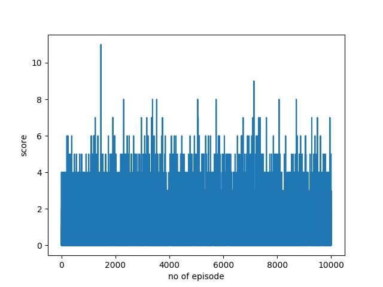

```python
## Test trained DQN
import random
import gym
import numpy as np
from keras.models import Model, Input
from keras.layers import Conv2D, Flatten, Dense, BatchNormalization
from keras.optimizers import Adam
from keras.preprocessing import image
from keras import losses
IMG_WIDTH = 48
IMG_HEIGHT = 48
AGENT_HISTORY_LENGTH = 4
NUM_OF_ACTIONS = 4
LEARNING_RATE = 0.000025
IMG_SIZE = (IMG_HEIGHT, IMG_WIDTH)
env = gym.make("Breakout-v4")

def pre_process_observation(observation):
        observation = observation[32:-17, 8:-8]
        img = image.array_to_img(observation, 'channels_last')
        img = img.convert('L')
        img = img.resize(IMG_SIZE)
        observation = image.img_to_array(img, 'channels_last')
        return np.squeeze(observation)

def get_predicted_action(sequence):
        prediction = Q.predict(np.asarray([np.stack(sequence, -1)]))[0]
        return np.argmax(prediction)

def get_model():
    input_layer = Input(shape=(IMG_HEIGHT, IMG_WIDTH, AGENT_HISTORY_LENGTH))
    layer = BatchNormalization()(input_layer)
    layer = Conv2D(32, (8, 8), strides=(4, 4), activation='relu', data_format="channels_last", padding='same')(layer)
    layer = BatchNormalization()(layer)
    layer = Conv2D(32, (4, 4), strides=(2, 2), activation='relu', data_format="channels_last", padding='same')(layer)
    layer = BatchNormalization()(layer)
    layer = Conv2D(64, (3, 3), strides=(1, 1), activation='relu', data_format="channels_last", padding='same')(layer)
    layer = Flatten()(layer)
    layer = BatchNormalization()(layer)
    layer = Dense(512, activation='relu')(layer)
    layer = BatchNormalization()(layer)
    output_layer = Dense(NUM_OF_ACTIONS)(layer)
    model = Model(input_layer, output_layer)
    model.compile(Adam(LEARNING_RATE), loss=losses.mean_squared_error, metrics=['accuracy'])
    return model

Q = get_model()
def test(total_episodes):
    # pickle.load()
    trained_model = get_model()
    trained_model.load_weights('weights.h5')
    rewards = []
    for episode in range(total_episodes):
        observation = env.reset()
        observation = pre_process_observation(observation)
        sequence = [observation]*AGENT_HISTORY_LENGTH
        done = False
        episode_reward = 0

        while not done:
            action = get_predicted_action(sequence)
            observation, reward, done, info = env.step(action)
            observation = pre_process_observation(observation)
            episode_reward += reward

        rewards.append(reward)

    print('Run %d episodes'%(total_episodes))
    print('Mean:', np.mean(rewards))

test(100)
```

The following github repository was used to generate graphs https://github.com/andi611/DQN-Deep-Q-Network-Atari-Breakout-Tensorflow since my code was taking longer to train.

```python
import numpy as np
import argparse
from agent_dqn import Agent_DQN
from environment import Environment
seed = 11037

class Arguments():
    do_render=False
    env_name=None
    test_dqn=False
    test_pg=False
    train_dqn=True
    train_pg=False
    video_dir=None


def parse():
	parser = argparse.ArgumentParser(description="runner")
	parser.add_argument('--env_name', default=None, help='environment name')
	parser.add_argument('--train_pg', action='store_true', help='whether train policy gradient')
	parser.add_argument('--train_dqn', action='store_true', help='whether train DQN')
	parser.add_argument('--test_pg', action='store_true', help='whether test policy gradient')
	parser.add_argument('--test_dqn', action='store_true', help='whether test DQN')
	parser.add_argument('--video_dir', default=None, help='output video directory')
	parser.add_argument('--do_render', action='store_true', help='whether render environment')
	args = parser.parse_args()
	return args


def run(args):
	if train_dqn:
		args = arguments()
		env_name = 'BreakoutNoFrameskip-v0'
		env = Environment(env_name, args, atari_wrapper=True)
		agent = Agent_DQN(env, args)
		print("n_sapce = ",agent.n_actions)
		agent.train()
		agent.plot()

	if args.test_dqn:
		env = Environment('BreakoutNoFrameskip-v0', args, atari_wrapper=True, test=True)
		agent = Agent_DQN(env, args)
		test(agent, env, total_episodes=100)


def test(agent, env, total_episodes=30):
	rewards = []
	env.seed(seed)
	for i in range(total_episodes):
		state = env.reset()
		done = False
		episode_reward = 0.0

		# playing one game
		while not done:
			action = agent.make_action(state, test=True)
			state, reward, done, info = env.step(action)
			episode_reward += reward

		rewards.append(episode_reward)
	print('Run %d episodes'%(total_episodes))
	print('Mean:', np.mean(rewards))


if __name__ == '__main__':
# 	args = parse()
# 	print(args)
    args = Arguments()
    run(args)
```

```
n_sapce =  4
Step: 23/1400000,  Episode: 1,  Action: 1,  Episode Reward: 0,  Epsilon: 1.00, Loss: 9.99990
Step: 90/1400000,  Episode: 2,  Action: 3,  Episode Reward: 1,  Epsilon: 1.00, Loss: 9.99990
Step: 113/1400000,  Episode: 3,  Action: 1,  Episode Reward: 0,  Epsilon: 1.00, Loss: 9.99990
Step: 134/1400000,  Episode: 4,  Action: 2,  Episode Reward: 0,  Epsilon: 1.00, Loss: 9.99990
Step: 159/1400000,  Episode: 5,  Action: 0,  Episode Reward: 0,  Epsilon: 1.00, Loss: 9.99990
Step: 228/1400000,  Episode: 6,  Action: 1,  Episode Reward: 1,  Epsilon: 1.00, Loss: 9.99990
Step: 251/1400000,  Episode: 7,  Action: 0,  Episode Reward: 0,  Epsilon: 1.00, Loss: 9.99990
Step: 274/1400000,  Episode: 8,  Action: 1,  Episode Reward: 0,  Epsilon: 1.00, Loss: 9.99990
Step: 295/1400000,  Episode: 9,  Action: 0,  Episode Reward: 0,  Epsilon: 1.00, Loss: 9.99990
Step: 318/1400000,  Episode: 10,  Action: 3,  Episode Reward: 0,  Epsilon: 1.00, Loss: 9.99990
Step: 341/1400000,  Episode: 11,  Action: 1,  Episode Reward: 0,  Epsilon: 1.00, Loss: 9.99990
Step: 362/1400000,  Episode: 12,  Action: 1,  Episode Reward: 0,  Epsilon: 1.00, Loss: 9.99990
Step: 383/1400000,  Episode: 13,  Action: 1,  Episode Reward: 0,  Epsilon: 1.00, Loss: 9.99990
Step: 404/1400000,  Episode: 14,  Action: 1,  Episode Reward: 0,  Epsilon: 1.00, Loss: 9.99990
Step: 427/1400000,  Episode: 15,  Action: 2,  Episode Reward: 0,  Epsilon: 1.00, Loss: 9.99990
Step: 450/1400000,  Episode: 16,  Action: 3,  Episode Reward: 0,  Epsilon: 1.00, Loss: 9.99990
Step: 551/1400000,  Episode: 17,  Action: 0,  Episode Reward: 2,  Epsilon: 1.00, Loss: 9.99990
Step: 574/1400000,  Episode: 18,  Action: 3,  Episode Reward: 0,  Epsilon: 1.00, Loss: 9.99990
Step: 597/1400000,  Episode: 19,  Action: 3,  Episode Reward: 0,  Epsilon: 1.00, Loss: 9.99990
Step: 620/1400000,  Episode: 20,  Action: 2,  Episode Reward: 0,  Epsilon: 1.00, Loss: 9.99990
Step: 689/1400000,  Episode: 21,  Action: 1,  Episode Reward: 1,  Epsilon: 1.00, Loss: 9.99990
Step: 710/1400000,  Episode: 22,  Action: 2,  Episode Reward: 0,  Epsilon: 1.00, Loss: 9.99990
Step: 733/1400000,  Episode: 23,  Action: 3,  Episode Reward: 0,  Epsilon: 1.00, Loss: 9.99990
Step: 756/1400000,  Episode: 24,  Action: 2,  Episode Reward: 0,  Epsilon: 1.00, Loss: 9.99990
Step: 828/1400000,  Episode: 25,  Action: 2,  Episode Reward: 1,  Epsilon: 1.00, Loss: 9.99990
Step: 851/1400000,  Episode: 26,  Action: 2,  Episode Reward: 0,  Epsilon: 1.00, Loss: 9.99990
Step: 874/1400000,  Episode: 27,  Action: 2,  Episode Reward: 0,  Epsilon: 1.00, Loss: 9.99990
Step: 897/1400000,  Episode: 28,  Action: 2,  Episode Reward: 0,  Epsilon: 1.00, Loss: 9.99990
Step: 920/1400000,  Episode: 29,  Action: 1,  Episode Reward: 0,  Epsilon: 1.00, Loss: 9.99990
Step: 1038/1400000,  Episode: 30,  Action: 2,  Episode Reward: 2,  Epsilon: 1.00, Loss: 9.99990
Step: 1061/1400000,  Episode: 31,  Action: 2,  Episode Reward: 0,  Epsilon: 1.00, Loss: 9.99990
Step: 1084/1400000,  Episode: 32,  Action: 3,  Episode Reward: 0,  Epsilon: 1.00, Loss: 9.99990
Step: 1155/1400000,  Episode: 33,  Action: 3,  Episode Reward: 1,  Epsilon: 1.00, Loss: 9.99990
Step: 1178/1400000,  Episode: 34,  Action: 0,  Episode Reward: 0,  Epsilon: 1.00, Loss: 9.99990
Step: 1250/1400000,  Episode: 35,  Action: 0,  Episode Reward: 1,  Epsilon: 1.00, Loss: 9.99990
Step: 1273/1400000,  Episode: 36,  Action: 0,  Episode Reward: 0,  Epsilon: 1.00, Loss: 9.99990
Step: 1296/1400000,  Episode: 37,  Action: 3,  Episode Reward: 0,  Epsilon: 1.00, Loss: 9.99990
Step: 1319/1400000,  Episode: 38,  Action: 2,  Episode Reward: 0,  Epsilon: 1.00, Loss: 9.99990
Step: 1346/1400000,  Episode: 39,  Action: 3,  Episode Reward: 0,  Epsilon: 1.00, Loss: 9.99990
```

[output cut: 139 more lines]

```
Step: 6081/1400000,  Episode: 179,  Action: 0,  Episode Reward: 1,  Epsilon: 0.99, Loss: 9.99990
Step: 6104/1400000,  Episode: 180,  Action: 0,  Episode Reward: 0,  Epsilon: 0.99, Loss: 9.99990
Step: 6173/1400000,  Episode: 181,  Action: 1,  Episode Reward: 1,  Epsilon: 0.99, Loss: 9.99990
Step: 6194/1400000,  Episode: 182,  Action: 0,  Episode Reward: 0,  Epsilon: 0.99, Loss: 9.99990
Step: 6266/1400000,  Episode: 183,  Action: 1,  Episode Reward: 1,  Epsilon: 0.99, Loss: 9.99990
Step: 6287/1400000,  Episode: 184,  Action: 1,  Episode Reward: 0,  Epsilon: 0.99, Loss: 9.99990
Step: 6308/1400000,  Episode: 185,  Action: 3,  Episode Reward: 0,  Epsilon: 0.99, Loss: 9.99990
Step: 6331/1400000,  Episode: 186,  Action: 0,  Episode Reward: 0,  Epsilon: 0.99, Loss: 9.99990
Step: 6354/1400000,  Episode: 187,  Action: 0,  Episode Reward: 0,  Epsilon: 0.99, Loss: 9.99990
Step: 6377/1400000,  Episode: 188,  Action: 1,  Episode Reward: 0,  Epsilon: 0.99, Loss: 9.99990
Step: 6398/1400000,  Episode: 189,  Action: 0,  Episode Reward: 0,  Epsilon: 0.99, Loss: 9.99990
Step: 6421/1400000,  Episode: 190,  Action: 1,  Episode Reward: 0,  Epsilon: 0.99, Loss: 9.99990
Step: 6444/1400000,  Episode: 191,  Action: 1,  Episode Reward: 0,  Epsilon: 0.99, Loss: 9.99990
Step: 6591/1400000,  Episode: 192,  Action: 3,  Episode Reward: 3,  Epsilon: 0.99, Loss: 9.99990
Step: 6617,  Episode: 192,  Action: 0,  Reward: 0,  Epsilon: 0.99385, Loss: 9.99990
```

[output not shown]

[output cut: 53 more lines]

[output not shown]

Average reward over 30 episodes

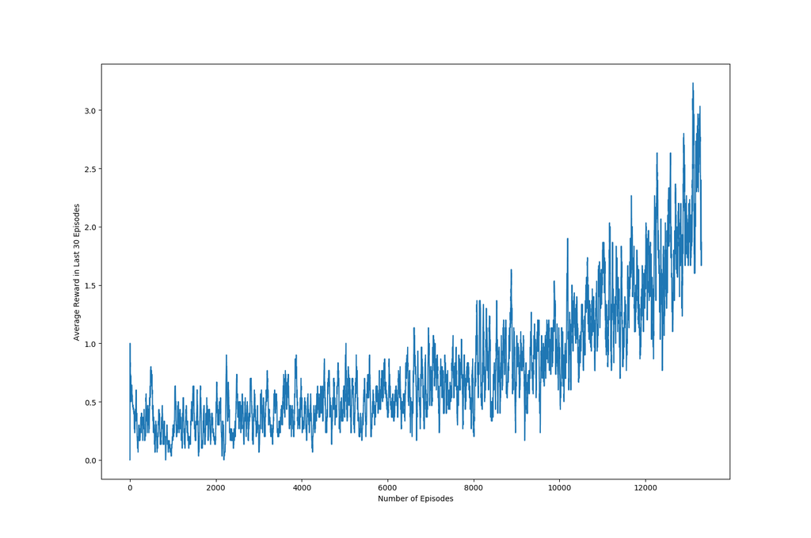

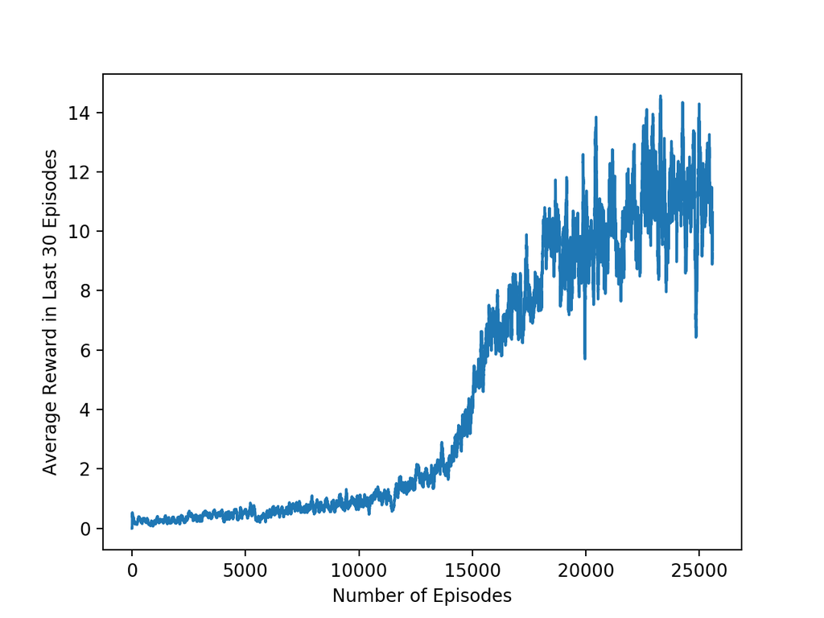

Training without wait or 'noop' operation gives poorer results for the same number of episodes, it is evident from following two graphs

Fig1. Training without wait option

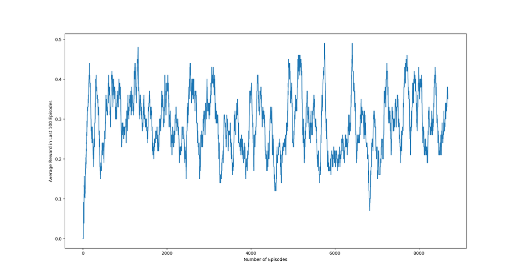

Fig2. We can see that scores arwe significantly lower than the similar graphs for enviroments with wait option.

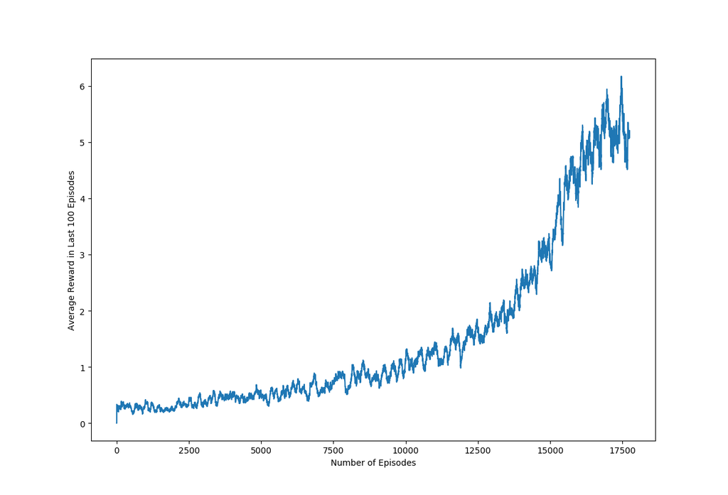

Training on Pong The action space is 6 instead of 4. Pong input image shape is (210, 160)

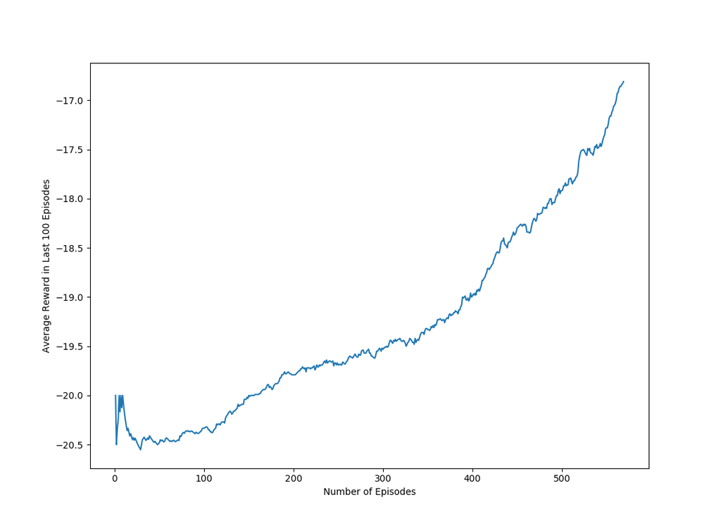